# Scratch_Model_and_SVM_Transfer

### Dataset

This dataset is called FER2013 and is available through Kaggle [here](https://www.kaggle.com/deadskull7/fer2013).

The dataset consists of 48x48 pixel grayscale images of faces. The faces have been automatically registered so that the face is more or less centered and occupies about the same amount of space in each image.

```python
train_X = np.load('np_data/train_X.npy')
train_X = np.expand_dims(train_X, -1)
test_X = np.load('np_data/test_X.npy')
test_X = np.expand_dims(test_X, -1)

train_X = train_X / 255.
test_X = test_X /255.

num_classes = 7
train_y = np.load('np_data/train_y.npy')
test_y = np.load('np_data/test_y.npy')

#Set aside validation set from test
test_X, validation_X, test_y, validation_y = train_test_split(test_X, test_y, test_size=0.6, random_state=23)

y_train = np_utils.to_categorical(train_y, num_classes)
y_test = np_utils.to_categorical(test_y, num_classes)
y_validation = np_utils.to_categorical(validation_y, num_classes)
```

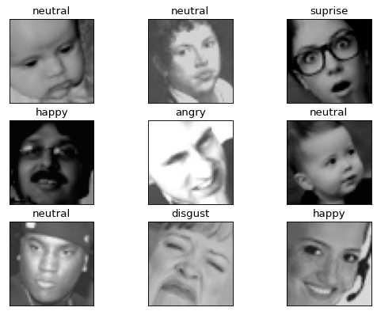

```python
datagen = ImageDataGenerator(rotation_range=25, horizontal_flip=0.5,channel_shift_range=.3)
# datagen.fit(train_X)
train_gen = datagen.flow(train_X, y_train, batch_size=32)
batch_size = 9
i=0
plt.figure(figsize=(8, 6), dpi=80)

for img_batch, batch_labels in datagen.flow(train_X, y_train, batch_size=9):
    for img in img_batch:
        plt.subplot(330 + 1 + i)
        img = np.repeat(img, 3, -1)
        ax = plt.gca()
        ax.axes.xaxis.set_visible(False)
        ax.axes.yaxis.set_visible(False)
        label = labels[np.argmax(batch_labels[i])]
        ax.set_title(label)
        plt.imshow(img)
        i=i+1
    if i >= batch_size:
        break
```

```
Training data available in 7 classes
```

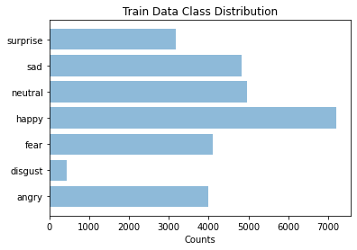

```python
print("Training data available in 7 classes")

food_classes = ('angry', 'disgust',	'fear', 'happy', 'neutral', 'sad', 'surprise')

y_pos = np.arange(len(food_classes))
counts = [list(train_y).count(i) for i in range(num_classes)]

plt.barh(y_pos, counts, align='center', alpha=0.5)
plt.yticks(y_pos, food_classes)
plt.xlabel('Counts')
plt.title('Train Data Class Distribution')
plt.show()
```

As seen in the distribution chart above, there is significant class invalance, so we'll need to use a especial technique to balance the distribution to make sure the model learns how to classify the minority classes properly.

> I applied SMOTE and Data Augmentation.

**Data augmentation** artificially expands the size of a training dataset by creating modi ed versions of images already in the dataset which can help enhance the model as accuracy since deep neural networks tend to perform better when trained on more data. But also, the variations on the images can help expose the model to a wider variety of situations which can make it more robust. Random horizontal flip and random rotation performed best out of all transformations I tried.

```python
#Create a new SMOTE dataset.
from imblearn.over_sampling import SMOTE

train_smote_X = np.load('np_data/train_X.npy')
train_smote_X = train_smote_X.flatten()
train_smote_X = train_smote_X.reshape(train_X.shape[0], -1)
train_smote_X.shape
sm = SMOTE(random_state=23)
X_smote, y_smote = sm.fit_resample(train_smote_X, train_y)
np.save('np_data/X_smote.npy', X_smote)
np.save('np_data/y_smote.npy', y_smote)
```

```python
#load SMOTE dataset
X_smote = np.load('np_data/X_smote.npy')
y_smote = np.load('np_data/y_smote.npy')
smote_X = X_smote.reshape(-1, 48,48)
smote_X = np.expand_dims(smote_X, -1)

smote_X = smote_X / 255.
smote_datagen = ImageDataGenerator(rotation_range=35,
                                   horizontal_flip=0.5,
                                   channel_shift_range=.4,
                                   vertical_flip=0.5
                                   )
smote_y = np_utils.to_categorical(y_smote, num_classes)
train_smote_gen = smote_datagen.flow(smote_X, smote_y,batch_size=32)

#generate a version with 3 channels for transfer learning with VGG16
smote_Xr = np.repeat(smote_X,3,-1)
validation_Xr = np.repeat(validation_X,3,-1)

trainr_smote_gen = smote_datagen.flow(smote_Xr, smote_y,batch_size=32)

test_Xr = np.repeat(test_X,3,-1)
```

## Model Training

I trained two separate models. The first one uses transfer learning to finetune a CNN with VGG weights, and the second one trains a CNN from random initialization.

### Transfer Learning with VGG

> Create a base pre-trained model using VGG16 weights and add average pooling and trainable fully-connected layers.

**Transfer Learning** is a method of constructing deep learning models by taking weights from a model trained for one task and using them as weight initialization for finetuning the model to perform a different task.

I took weights from a VGG16 model which has been pretrained on the ImageNet dataset and exclude the model's top layers which were used for the final ImageNet classification task. I add an average pooling layer to reduce the dimensions and a softmax activation layer to perform the final classification for this task.

##### Finetune VGG16 transfer model

```python
# create the base pre-trained model
base_model = VGG16(weights='imagenet', include_top=False)

# add a global spatial average pooling layer
x = base_model.output
x = GlobalAveragePooling2D()(x)

#add softmax layer
predictions = Dense(7, activation='softmax')(x)

transfer_model = Model(inputs=base_model.input, outputs=predictions)

# train only the top layers and freeze the rest
for layer in transfer_model.layers[:11]:
   layer.trainable = False
for layer in transfer_model.layers[11:]:
   layer.trainable = True

transfer_model.compile(loss='categorical_crossentropy',
              optimizer= Adam(lr=0.0001),
              metrics=['accuracy'])

#reduce learning rate when loss on validation set has stopped improving
lr_reducer = ReduceLROnPlateau(monitor='val_loss', factor=0.3, patience=5, verbose=1)

#stop training when loss on validation set has stopped improving
early_stopper = EarlyStopping(monitor='val_loss', min_delta=0, patience=10, verbose=1, mode='auto')

checkpointer = ModelCheckpoint(filepath='model.vgg16transfer',
                               verbose=1,save_best_only=True, monitor='val_loss')

# transfer_model.load_weights('model.vgg16transfer')

history = transfer_model.fit(trainr_smote_gen,
          batch_size=32,
          epochs=40,
          verbose=1,
          validation_data=(validation_Xr, y_validation),
          shuffle=True,
          callbacks=[lr_reducer, early_stopper, checkpointer])

import json
# Get the dictionary containing each metric and the loss for each epoch
history_dict = history.history
# Save it under the form of a json file
json.dump(str(history_dict), open('model.vgg16transfer.history', 'w'))
```

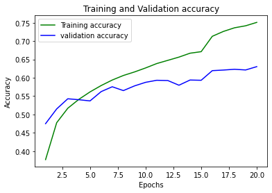

```python
acc_train = history.history['accuracy']
acc_val = history.history['val_accuracy']
epochs = range(1,len(acc_train)+1)
plt.plot(epochs, acc_train, 'g', label='Training accuracy')
plt.plot(epochs, acc_val, 'b', label='validation accuracy')
plt.title('Training and Validation accuracy')
plt.xlabel('Epochs')
plt.ylabel('Accuracy')
plt.legend(loc='best')
plt.show()
```

```
Accuracy on Test Data:  0.6241727621037966
```

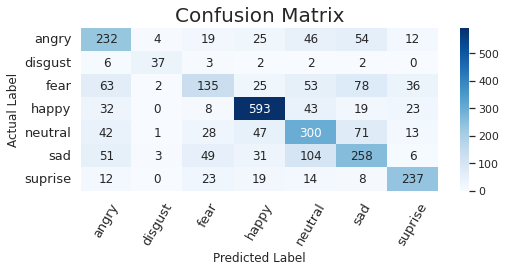

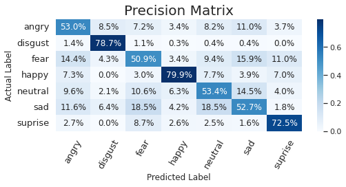

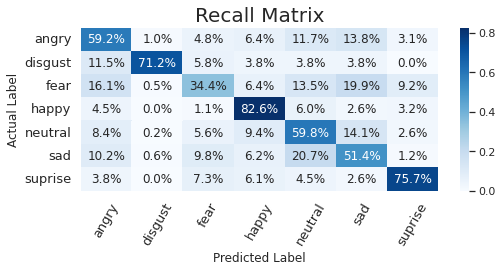

```python
preds = np.argmax(transfer_model.predict(test_Xr), axis=1)
print("\nAccuracy on Test Data: ", accuracy_score(test_y, preds))
return_confusion_matrix(test_y,preds)
```

#### Train a CNN from Scratch.

##### Define model architecture

```python
num_of_filters = 32
model = Sequential()

model.add(Conv2D(filters=num_of_filters, kernel_size=(3, 3), activation='relu', input_shape=(48, 48, 1)))
model.add(BatchNormalization())
model.add(Conv2D(num_of_filters, kernel_size=(3, 3), activation='relu', padding='same'))
# model.add(Dropout(.4))
model.add(BatchNormalization())
model.add(MaxPooling2D(pool_size=(2, 2), strides=(2, 2)))
model.add(Dropout(.3))

model.add(Conv2D(2*num_of_filters, kernel_size=(3, 3), activation='relu', padding='same'))
model.add(BatchNormalization())
# model.add(Dropout(.4))
model.add(Conv2D(2*num_of_filters, kernel_size=(3, 3), activation='relu', padding='same'))
# model.add(Dropout(.4))
model.add(BatchNormalization())
model.add(MaxPooling2D(pool_size=(2, 2), strides=(2, 2)))
model.add(Dropout(.3))

model.add(Conv2D(2*2*num_of_filters, kernel_size=(3, 3), activation='relu', padding='same'))
model.add(BatchNormalization())
model.add(Conv2D(2*2*num_of_filters, kernel_size=(3, 3), activation='relu', padding='same'))
# model.add(Dropout(.4))
model.add(BatchNormalization())
model.add(MaxPooling2D(pool_size=(2, 2), strides=(2, 2)))
model.add(Dropout(.3))


model.add(Conv2D(2*2*2*num_of_filters, kernel_size=(3, 3), activation='relu', padding='same'))
model.add(BatchNormalization())
model.add(Conv2D(2*2*2*num_of_filters, kernel_size=(3, 3), activation='relu', padding='same'))
# model.add(Dropout(.4))
model.add(BatchNormalization())
model.add(GlobalAveragePooling2D())
# model.add(Dropout(.5))


# model.add(Flatten())

# model.add(Dense(2*2*2*num_of_filters, activation='relu'))
# model.add(Dense(2*2*num_of_filters, activation='relu'))
# model.add(Dense(2*num_of_filters, activation='relu'))

model.add(Dense(7, activation='softmax'))
model.summary()

initial_weights = model.get_weights()
# model.load_weights('model.lab4.hdf5')
```

```
Model: "sequential"
_________________________________________________________________
 Layer (type)                Output Shape              Param #
=================================================================
 conv2d (Conv2D)             (None, 46, 46, 32)        320

 batch_normalization (BatchN  (None, 46, 46, 32)       128
 ormalization)

 conv2d_1 (Conv2D)           (None, 46, 46, 32)        9248

 batch_normalization_1 (Batc  (None, 46, 46, 32)       128
 hNormalization)

 max_pooling2d (MaxPooling2D  (None, 23, 23, 32)       0
 )

 dropout (Dropout)           (None, 23, 23, 32)        0

 conv2d_2 (Conv2D)           (None, 23, 23, 64)        18496

 batch_normalization_2 (Batc  (None, 23, 23, 64)       256
 hNormalization)

 conv2d_3 (Conv2D)           (None, 23, 23, 64)        36928

 batch_normalization_3 (Batc  (None, 23, 23, 64)       256
 hNormalization)

 max_pooling2d_1 (MaxPooling  (None, 11, 11, 64)       0
 2D)

 dropout_1 (Dropout)         (None, 11, 11, 64)        0

 conv2d_4 (Conv2D)           (None, 11, 11, 128)       73856

 batch_normalization_4 (Batc  (None, 11, 11, 128)      512
 hNormalization)

 conv2d_5 (Conv2D)           (None, 11, 11, 128)       147584
```

[output cut: 14 more lines]

```
 conv2d_7 (Conv2D)           (None, 5, 5, 256)         590080

 batch_normalization_7 (Batc  (None, 5, 5, 256)        1024
 hNormalization)

 global_average_pooling2d_3   (None, 256)              0
 (GlobalAveragePooling2D)

 dense_3 (Dense)             (None, 7)                 1799

=================================================================
Total params: 1,177,319
Trainable params: 1,175,399
Non-trainable params: 1,920
_________________________________________________________________
```

##### Finetune

```python
model = model
model.set_weights(initial_weights)

model.compile(loss='categorical_crossentropy',
              optimizer=Adam(lr=0.001),
              metrics=['accuracy'])

# reduce learning rate when loss on validation set has stopped improving
lr_reducer = ReduceLROnPlateau(monitor='val_loss', factor=0.3, patience=5, verbose=1)

#stop training when loss on validation set has stopped improving
early_stopper = EarlyStopping(monitor='val_loss', min_delta=0, patience=15, verbose=1, mode='auto')

checkpointer = ModelCheckpoint(filepath='model.lab31.hdf5',
                               verbose=1,save_best_only=True, monitor='val_loss')

history = model.fit(train_smote_gen,
          epochs=40,
          verbose=1,
          validation_data=(validation_X, y_validation),
          shuffle=True,
          callbacks=[lr_reducer, early_stopper, checkpointer])

# Get the dictionary containing each metric and the loss for each epoch
history_dict = history.history
# Save it under the form of a json file
json.dump(str(history_dict), open('model.lab31.hdf5.history', 'w'))
```

```
Accuracy on Test Data:  0.6287008011145943
```

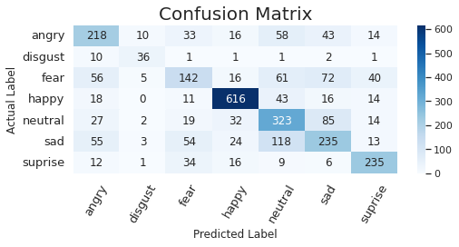

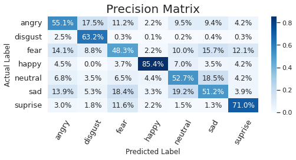

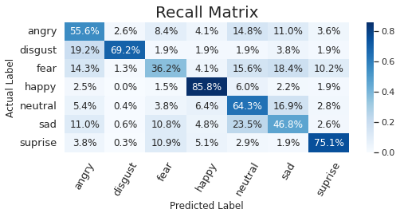

```python
preds = np.argmax(model.predict(test_X), axis=1)
print("\nAccuracy on Test Data: ", accuracy_score(test_y, preds))
return_confusion_matrix(test_y,preds)
```

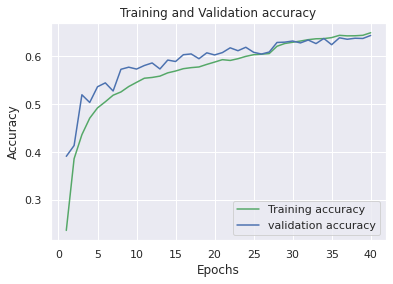

```python
acc_train = history.history['accuracy']
acc_val = history.history['val_accuracy']
epochs = range(1,len(acc_train)+1)
plt.plot(epochs, acc_train, 'g', label='Training accuracy')
plt.plot(epochs, acc_val, 'b', label='validation accuracy')
plt.title('Training and Validation accuracy')
plt.xlabel('Epochs')
plt.ylabel('Accuracy')
plt.legend(loc='best')
plt.show()
```

### Tests on celebrity images

> We can test the model on random images obtained from the web.

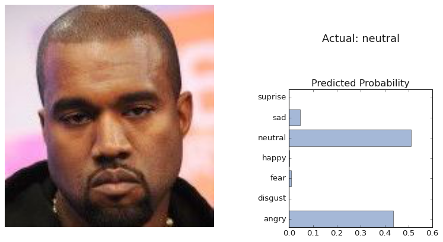

```python
#test on image from folder
return_prediction('Test Images/neutral/kanye.jpg', model)
```

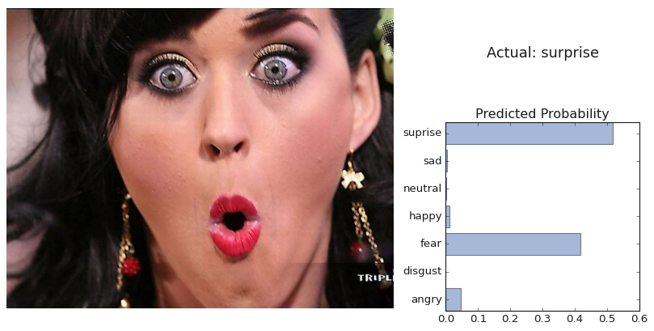

```python
return_prediction('Test Images/surprise/katy.jpg', model)
```

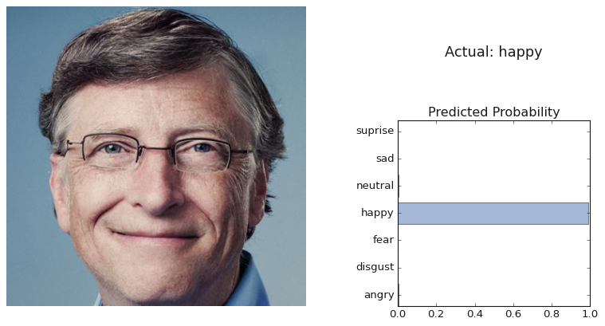

```python
#test on image from folder
return_prediction('Test Images/happy/gates.jpeg', model)
```

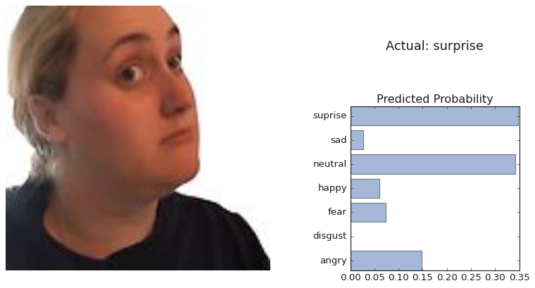

```python
return_prediction('Test Images/surprise/kambucha.jpg', model)
```